# Part I - Pisa

## Bivariate Exploration

### Wealth and socioeconomic status—do they correlate in any way

```
0.685261572473708
```

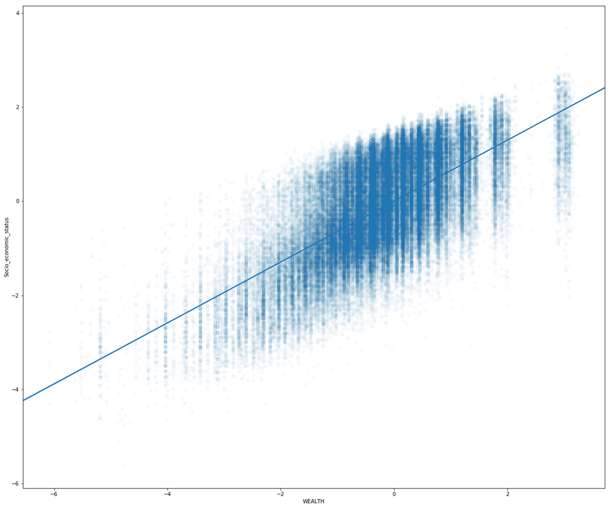

```python
plt.figure (figsize = [20,17])
sb.regplot(x= 'WEALTH', y='Socio_economic_status', data = pisa, color =base_color, scatter_kws={'alpha':1/40} );
pisa['WEALTH'].corr(pisa['Socio_economic_status'])
```

> There is a fairly Strong positive correlation of 0.685261572473708 between the two.

### How much of an impact can wealth have on grades?

```
0.10462518279120543
```

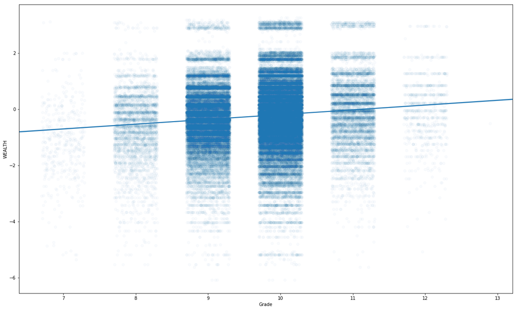

```python
plt.figure (figsize = [20,12])
sb.regplot(y= 'WEALTH', x='Grade', data = pisa, color =base_color, x_jitter=0.3, scatter_kws={'alpha':1/40});
pisa['WEALTH'].corr(pisa['Grade'])
```

> there is a negligible positive correlation between the two, which effectively negates any meaningful relationship between wealth and grade.

### How much of an impact can Socio_economic_status have on grades?

```
0.1071354771195073
```

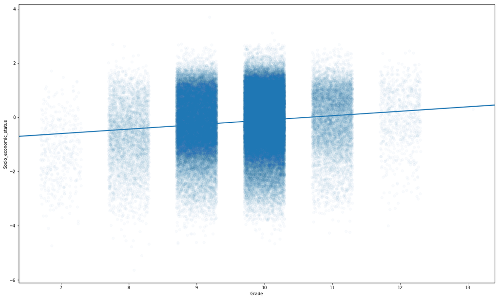

```python
plt.figure (figsize = [20,12])
sb.regplot(y= 'Socio_economic_status', x='Grade', data = pisa, color =base_color, x_jitter=0.3, scatter_kws={'alpha':1/40});
pisa['Socio_economic_status'].corr(pisa['Grade'])
```

Given that wealth and socioeconomic status have a strong positive correlation, it makes sense that their correlation with academic performance is minimal.

### How are students gendered across countries?

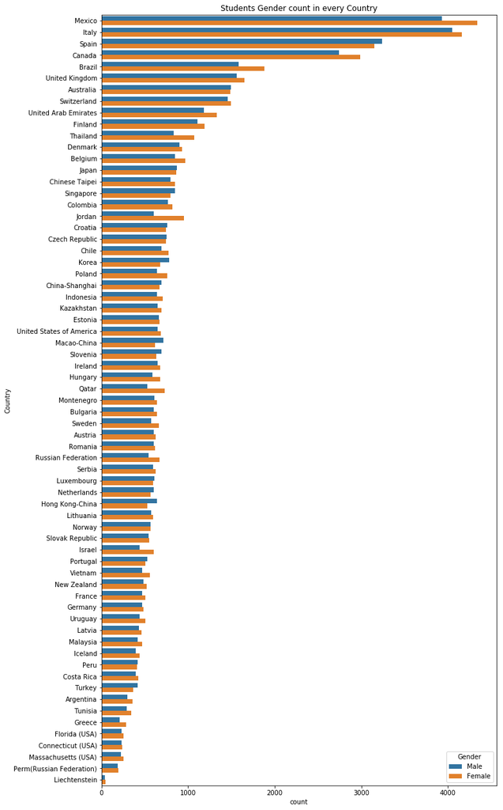

```python
plt.figure(figsize=[11,22])

order= pisa['Country'].value_counts().index
sb.countplot(data=pisa,y='Country',order=order,hue='Gender' )

plt.title('Students Gender count in every Country');
plt.legend( title = 'Gender');
```

> The number of female exam participants is marginally higher than the number of male participants.